# Age_vs_Performance_Study

## Relationship Between Policy Awareness and Student Opinions

In this section, we explore how awareness of age-related admission policies influences students' opinions on performance, readiness, and cognitive ability.

- **Awareness vs. Support for Policy:** Among students unaware of the 16-year-old policy, only 40% support it. In contrast, 67% of those aware of the policy agree with it. This suggests that awareness plays a significant role in shaping positive opinions toward the policy.
- **Awareness vs. Belief in Age Impact on Performance:** A striking 88% of those unaware of the policy *do not* believe age affects academic performance, whereas 41.8% of aware students believe it does. Again, awareness appears linked with greater sensitivity to how age impacts outcomes.
- **Awareness vs. Readiness Belief:** Interestingly, this time, 88% of students who are unaware of the 16-year-old policy believe age affects readiness — much higher than the 69.4% agreement rate among the aware group. This could indicate that some respondents recognize readiness differences regardless of policy awareness.
- **New Policy Awareness vs. Performance Belief:** Among those aware of the new policy, 56.7% believe students above 18 perform better than younger peers — compared to just 39.2% in the unaware group. Awareness is again associated with stronger belief in age-related performance benefits.
- **New Policy Awareness vs. Cognition Above 18:** There’s a split here — those aware of the policy are more neutral (32.9%) and less likely to agree (38.6%) than the unaware group (49.2% agree). This suggests that awareness might encourage more balanced or cautious views rather than outright agreement.
- **New Policy Awareness vs. Cognition Below 18:** Similarly, those aware of the policy lean more toward neutrality (38.4%), while the unaware group shows slightly more support (36.5% agree). Once again, awareness seems to moderate strong opinions.

**Overall Insight:** Awareness of admission age policies clearly influences students' perspectives — often increasing agreement with the policy and belief in age-performance links. However, when it comes to cognitive ability, policy awareness seems to invite more neutrality and nuanced thinking.

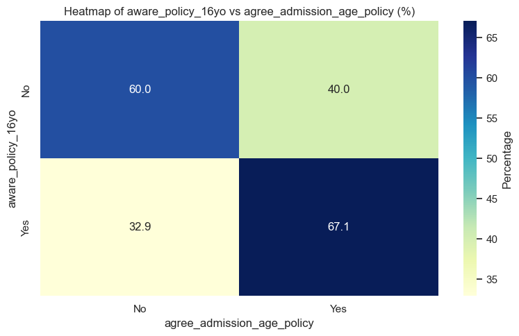

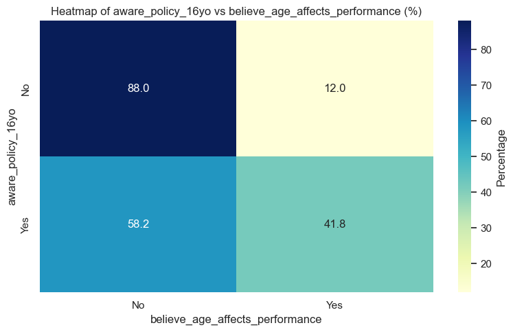

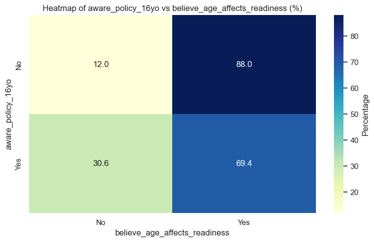

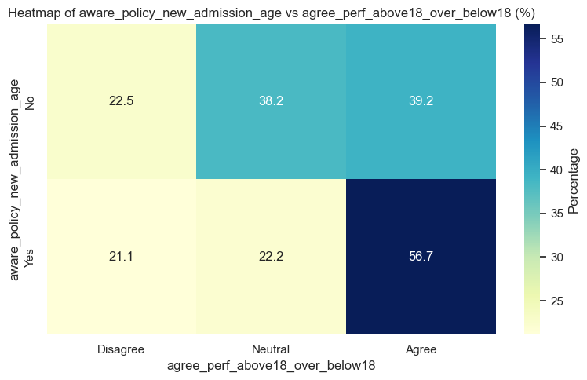

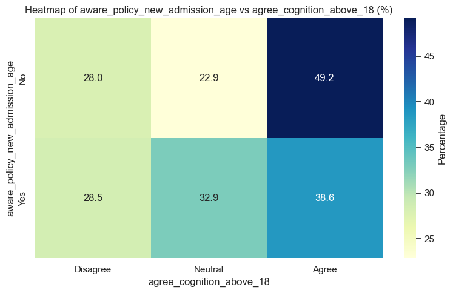

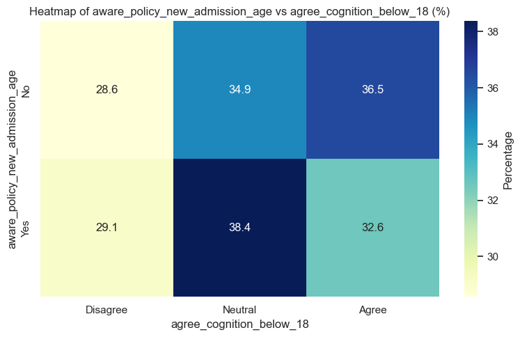

```python
# Set styles and deeper palette
sns.set(style='whitegrid')
plt.rcParams.update({'font.size': 12})

# Fixed order for Degree_Class (ordinal)
degree_order = ['First Class', 'Second Class Upper', 'Second Class Lower', 'Third Class', 'Pass']
df['Degree_Class'] = pd.Categorical(df['Degree_Class'], categories=degree_order, ordered=True)

# --- 1. Policy Awareness vs Opinions Cross-tabs & Heatmaps

policy_awareness_cols = ['aware_policy_16yo', 'aware_policy_new_admission_age']
opinion_cols_16yo = ['agree_admission_age_policy', 'believe_age_affects_performance', 'believe_age_affects_readiness']
opinion_cols_new_adm = ['agree_perf_above18_over_below18', 'agree_cognition_above_18', 'agree_cognition_below_18']

def plot_heatmap_crosstab(row_var, col_var, normalize='index'):
    ct = pd.crosstab(df[row_var], df[col_var], normalize=normalize) * 100
    plt.figure(figsize=(8, 5))
    sns.heatmap(ct, annot=True, fmt='.1f', cmap='YlGnBu', cbar_kws={'label': 'Percentage'})
    plt.title(f'Heatmap of {row_var} vs {col_var} (%)')
    plt.ylabel(row_var)
    plt.xlabel(col_var)
    plt.tight_layout()
    plt.show()

# Plot for aware_policy_16yo vs related opinions
for opinion_col in opinion_cols_16yo:
    plot_heatmap_crosstab('aware_policy_16yo', opinion_col)

# Plot for aware_policy_new_admission_age vs related opinions
for opinion_col in opinion_cols_new_adm:
    plot_heatmap_crosstab('aware_policy_new_admission_age', opinion_col)
```

## Chi-square Test: Age Group vs. Degree Class

To statistically assess whether there's an association between students' age groups and their final degree classifications, a Chi-square test of independence was conducted.

- **Chi-square Statistic:** 16.993
- **Degrees of Freedom:** 8
- **P-value:** 0.0302

### Interpretation:

Since the p-value is less than 0.05, we reject the null hypothesis of independence. This means:

> **There is a statistically significant association between a student’s age group and their degree class.**

In practical terms, the age group a student falls into appears to have a meaningful relationship with the class of degree they eventually graduate with. This aligns with earlier observations from the bar charts, where older students (especially those 20 and above) had higher proportions of First Class and Second Class Upper degrees.

```python
# Cross-tabulation of Degree_Class by Age_Group
ct = pd.crosstab(df['Degree_Class'], df['Age_Group'])

# Chi-square test
chi2, p, dof, expected = chi2_contingency(ct)

print("Chi-square Test for Degree_Class vs Age_Group")
print(f"Chi-square Statistic: {chi2:.3f}")
print(f"Degrees of Freedom: {dof}")
print(f"P-value: {p:.4f}")

# Interpretation
alpha = 0.05
if p < alpha:
    print("Result: There is a statistically significant association between Age Group and Degree Class (reject H0).")
else:
    print("Result: No statistically significant association between Age Group and Degree Class (fail to reject H0).")
```

```
Chi-square Test for Degree_Class vs Age_Group
Chi-square Statistic: 16.993
Degrees of Freedom: 8
P-value: 0.0302
Result: There is a statistically significant association between Age Group and Degree Class (reject H0).
```

## Statistical Tests: Relationship Between Opinions and Degree Class

### Chi-square Tests (Yes/No Variables vs. Degree Class)

We conducted Chi-square tests to examine whether binary (Yes/No) responses on various questions are associated with the final **Degree Class** of students.

| Variable | Chi² | P-value | Conclusion |
| --- | --- | --- | --- |
| aware_policy_16yo | 4.315 | 0.3651 | ❌ No significant association |
| agree_admission_age_policy | 6.974 | 0.1373 | ❌ No significant association |
| believe_age_affects_performance | 6.186 | 0.1857 | ❌ No significant association |
| believe_age_affects_maturity | 3.017 | 0.5550 | ❌ No significant association |
| believe_age_affects_readiness | 3.604 | 0.4622 | ❌ No significant association |
| aware_policy_new_admission_age | 0.959 | 0.9159 | ❌ No significant association |

**Insight:** None of the binary opinion-based variables showed a statistically significant association with Degree Class. This suggests that simply agreeing or disagreeing with these policies or beliefs doesn’t strongly differentiate academic outcomes.

### Spearman Correlation (Likert-Scale vs. Degree Class)

We used Spearman's rank correlation to assess whether Likert-scale ratings (on cognition and performance) relate to students' academic performance.

| Variable | Spearman ρ | P-value | Conclusion |
| --- | --- | --- | --- |
| agree_cognition_above_18 | 0.110 | 0.0426 | ✅ Significant correlation |
| agree_cognition_below_18 | 0.046 | 0.3710 | ❌ No significant correlation |
| agree_perf_above18_over_below18 | 0.049 | 0.3997 | ❌ No significant correlation |

```python
import scipy.stats as stats

# --- 1. Ordinal encoding for Degree_Class and Likert variables ---

# Degree_Class encoding
degree_map = {
    'First Class': 1,
    'Second Class Upper': 2,
    'Second Class Lower': 3,
    'Third Class': 4,
    'Pass': 5
}
df['Degree_Class_num'] = df['Degree_Class'].map(degree_map)

# Define Likert ordinal mapping
likert_map = {
    'Strongly disagree': 1,
    'Disagree': 2,
    'Neutral': 3,
    'Agree': 4,
    'Strongly agree': 5
}

# Likert columns list
likert_cols = [
    'agree_cognition_above_18',
    'agree_cognition_below_18',
    'agree_perf_above18_over_below18'
]

# Encode Likert columns
for col in likert_cols:
    df[col + '_num'] = df[col].map(likert_map)

# Yes/No columns list
yesno_cols = [
    'aware_policy_16yo',
    'agree_admission_age_policy',
    'believe_age_affects_performance',
    'believe_age_affects_maturity',
    'believe_age_affects_readiness',
    'aware_policy_new_admission_age'
]

# Encode Yes/No columns to numeric for chi-square (Yes=1, No=0)
yesno_map = {'Yes': 1, 'No': 0}
for col in yesno_cols:
    df[col + '_num'] = df[col].map(yesno_map)

# --- 2. Chi-square tests for Yes/No variables vs Degree_Class (categorical) ---

print("Chi-square tests: Yes/No variables vs Degree_Class\n")
for col in yesno_cols:
    contingency = pd.crosstab(df[col], df['Degree_Class'])
    chi2, p, dof, expected = stats.chi2_contingency(contingency)
    print(f"{col}: chi2 = {chi2:.3f}, p-value = {p:.4f}")
    if p < 0.05:
        print("  --> Significant association\n")
    else:
        print("  --> No significant association\n")

# --- 3. Spearman correlations for Likert variables vs Degree_Class_num ---

print("\nSpearman correlations: Likert variables vs Degree_Class_num\n")
for col in likert_cols:
    clean_df = df[[col + '_num', 'Degree_Class_num']].dropna()
    corr, p = stats.spearmanr(clean_df[col + '_num'], clean_df['Degree_Class_num'])
    print(f"{col}: Spearman rho = {corr:.3f}, p-value = {p:.4f}")
    if p < 0.05:
        print("  --> Significant correlation\n")
    else:
        print("  --> No significant correlation\n")
```

```
Chi-square tests: Yes/No variables vs Degree_Class

aware_policy_16yo: chi2 = 4.315, p-value = 0.3651
  --> No significant association

agree_admission_age_policy: chi2 = 6.974, p-value = 0.1373
  --> No significant association

believe_age_affects_performance: chi2 = 6.186, p-value = 0.1857
  --> No significant association

believe_age_affects_maturity: chi2 = 3.017, p-value = 0.5550
  --> No significant association

believe_age_affects_readiness: chi2 = 3.604, p-value = 0.4622
  --> No significant association

aware_policy_new_admission_age: chi2 = 0.959, p-value = 0.9159
  --> No significant association


Spearman correlations: Likert variables vs Degree_Class_num

agree_cognition_above_18: Spearman rho = 0.110, p-value = 0.0426
  --> Significant correlation

agree_cognition_below_18: Spearman rho = 0.046, p-value = 0.3710
  --> No significant correlation

agree_perf_above18_over_below18: Spearman rho = 0.049, p-value = 0.3997
  --> No significant correlation
```

## Conclusion: Summary of Key Findings

This analysis explored how age and related policy opinions correlate with academic performance among students across various Nigerian tertiary institutions. Below are the most important insights gathered:

### Demographic Overview

- **Gender:** The responses were fairly balanced, with a slight male majority (54.3%).
- **Institution Type:** Federal Universities dominated the sample (66.9%), followed by State Universities (19.2%).
- **Age Distribution:** Over half of respondents were aged **20 and above** (50.1%), which provided a good base for age-related comparisons.
- **Entry Mode & Level:** Most students entered via **JAMB** (90.1%) and were in **100 level** (36.0%), giving a fresh academic perspective.

### Degree Class Patterns

- The most common degree class was **Second Class Upper (47.1%)**, while **First Class** and **Second Class Lower** followed.
- **Age Group vs Degree Class:** Older students (20+) generally achieved higher classifications, with the highest proportion of **First Class** and **Second Class Upper** degrees.
- **Academic Level vs Degree Class:** Middle levels (300L and 400L) had a better spread of top classifications than 100L and 500L, where extremes like **Pass** and **Third Class** were more concentrated.

### Policy Awareness and Beliefs

- An overwhelming **94.5%** were aware of the **16-year minimum admission age policy**, and **65.6%** agreed with it.
- Majority believe that age affects **performance (59.8%)**, **maturity (53.6%)**, and especially **readiness (70.4%)** for higher education.
- Awareness of the **new policy revision** was moderate (66.4%), showing room for improved communication.

### Perception of Cognition and Performance

- **42.2%** agreed that students **above 18** possess better cognitive ability, with virtually no one strongly agreeing or disagreeing.
- Responses about **students below 18** showed more uncertainty, with **37.2% staying neutral**.
- When asked directly, **50.7%** agreed that students **above 18 perform better** academically.

### Statistical Tests

- A **Chi-square test confirmed** a **significant relationship between age group and degree class** (p = 0.0302).
- However, **no Yes/No opinion question** showed a statistically significant link to academic performance.
- Only **"agree_cognition_above_18"** had a **significant Spearman correlation** with degree class (ρ = 0.110, p = 0.0426), indicating a weak but relevant association.

### Final Takeaway

Older students (20+) tend to perform better, and there’s a subtle but noteworthy relationship between **belief in cognitive maturity above 18** and academic success. However, general policy awareness and opinions don’t appear to significantly impact actual performance outcomes. These findings suggest that while age may matter, it's the student's readiness and maturity—rather than mere awareness or opinion—that influence academic achievement.